# Stupidest sampler presentation

## GDP grows with population

but it is unlikely to be twice as big for a population that is twice as big.

(Again, to avoid so called “Galton’s fallacy”, remember that this doe not prove any causation, because we do not have GDP or population in time series).

## We can summarize parameters nicely graphicaly

```r
plot(NULL,xlim=c(-2,2),ylim=c(3.5,0.5),xlab="parameter value",ylab="",yaxt="n")
axis(2,at=c(1,2,3),labels=c("a","b","sigma"),las=2)
abline(h=1:3)
toplot<-samples$a
dens<-density(toplot)
sc<-0.1 #You need to define a scaler not to draw to big density plots
polygon(dens$x,1-dens$y*sc,col=4)
lines(PI(toplot,prob=0.95),c(1,1),lwd=3)
points(mean(toplot),1,lwd=2,cex=1.2,bg=0,pch=21)
```

## We can summarize parameters nicely graphicaly

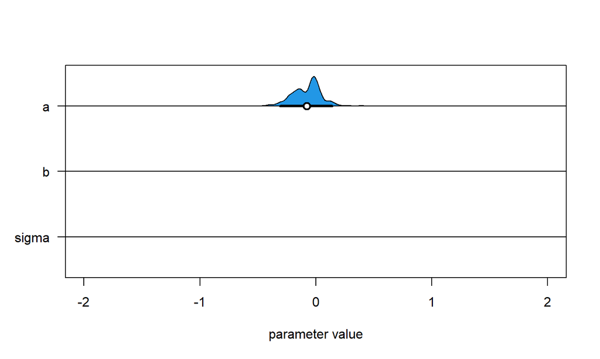

## I can pack this to a nice function

```r
drawDist<-function(toplot,y,sc=0.1){
  dens<-density(toplot)
  polygon(dens$x,y-dens$y*sc,col=4)
  lines(PI(toplot,prob=0.95),c(y,y),lwd=3)
  points(mean(toplot),y,lwd=2,cex=1.2,bg=0,pch=21)
}
```

## Plot with all parameters

```r
plot(NULL,xlim=c(-2,2),ylim=c(3.5,0.5),xlab="parameter value",ylab="",yaxt="n")
axis(2,at=c(1,2,3),labels=c("a","b","sigma"),las=2)
abline(h=1:3)
drawDist(samples$a,y=1)
drawDist(samples$b,y=2)
drawDist(samples$sigma,y=3)
abline(v=seq(-2,2,1),lty=2)
```

## Plot with all parameters

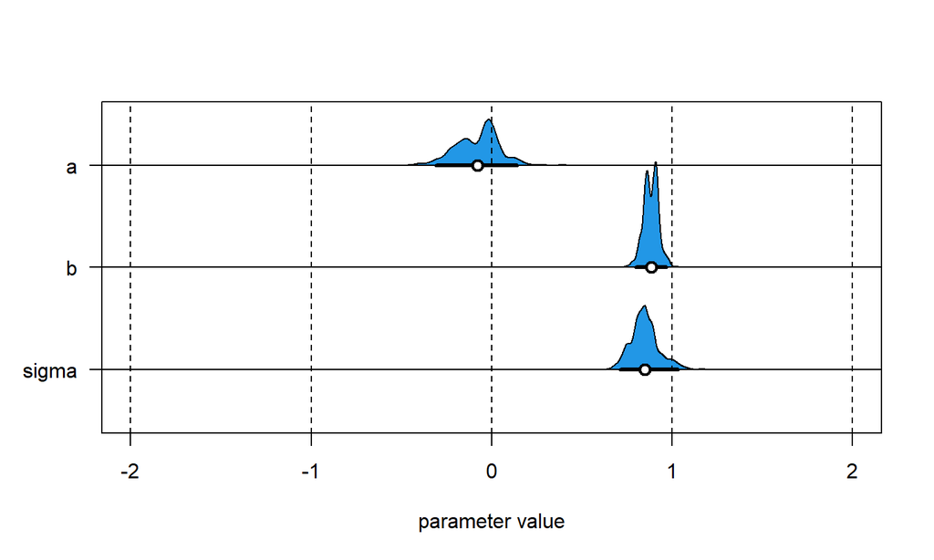

## The last thing that we can plot

is the correlation between parameter values across samples. This is something that you usually put only in the supplement, but you should nevertheless check it out.

## There are many ways how to do it

but we can go with simple pairs function

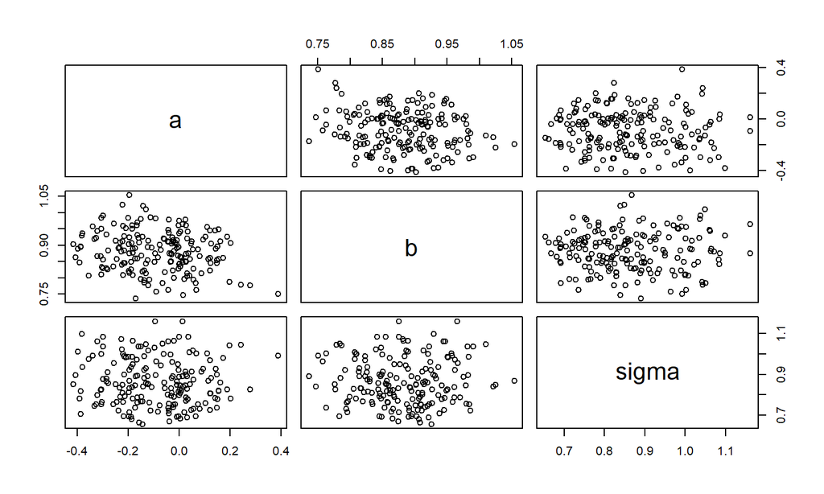

```r
pairs(samples[,1:3])
```

It does not look like a complicated intercorrelated posterior.

## Why are samplers so useful?

There was no need to divide anything by a large sum. The big divisor in the denominator is the same for all hypotheses.

All sampling techniques that we will introduce use this awesome fact and they just output a random subset of a continuum of plausible hypothesis.

## Why are samplers so useful?

Our sampler explicitly divides the raffle into two steps to bring closer the idea of hypothesis \(\text{prior} * \text{data likelihood}\) product. (Remember the forking paths from way above.) It is obviously much more effective to do it all in a single step. Stupidest sampler still generates a lot of junk per one random hypothesis that ends up in the final set of samples. Most samplers are more effective.

## Best sampler ever?

```r
#We need to prepare a data for it in nicer form
clean.d<-list(pop=best$population,
              gdp=best$totalGDP)

model<-ulam(alist(
  gdp ~ dnorm(a+b*pop,sigma),
  a ~ dnorm(0,1),
  b ~ dnorm(0,1),
  sigma ~ dexp(1)
),data=clean.d,chains=4,cores=4)
```

## Quick summary

```r
precis(model) #It is almost identical to the stupidest sampler
```

```
##              mean         sd       5.5%     94.5%    n_eff     Rhat4
## a     -0.09402935 0.11990283 -0.2851966 0.1015044 1466.529 0.9988355
## b      0.88459598 0.04612236  0.8109301 0.9568115 1763.823 0.9991957
## sigma  0.85432478 0.08373592  0.7324284 0.9967275 1704.227 0.9991536
```

## Extracting samples is easy

```r
post<-extract.samples(model)
```

## TASK 1

**Visualize the parameter values from the posterior (object post).** If you struggle, you can find the solution in TASK_SOLUTIONS.R line 1

## TASK 2

**Draw the prediction line and the 99% Percentile Compatibility interval around it** If you struggle, you can find the solution in TASK_SOLUTIONS.R line 11

## Solution

## Plot parameter estimates

```r
plot(NULL,xlim=c(-2,2),ylim=c(3.5,0.5),xlab="parameter value",ylab="",yaxt="n")
axis(2,at=c(1,2,3),labels=c("a","b","sigma"),las=2)
abline(h=1:3)
drawDist(post$a,y=1)
drawDist(post$b,y=2)
drawDist(post$sigma,y=3)
abline(v=seq(-2,2,1),lty=2)
```

## Plot parameter estimates

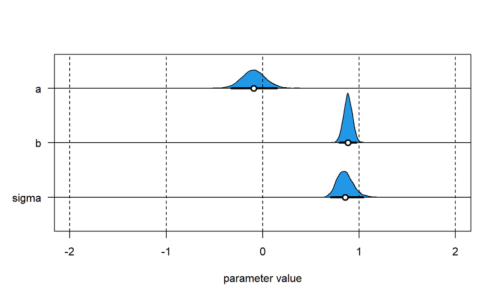

## Plot regression line and CI

Notice the prob=0.99

```r
x<-seq(-7,8,0.01)
y<-sapply(1:length(post$a),function(i){post$a[i]+post$b[i]*x})
muy<-apply(y,1,mean)
CIy<-apply(y,1,PI,prob=0.99)

myplot(best$population,best$totalGDP)
points(0,0,col=2,pch=16)
lines(x,muy)
shade(CIy,x)
```

## Plot regression line and CI

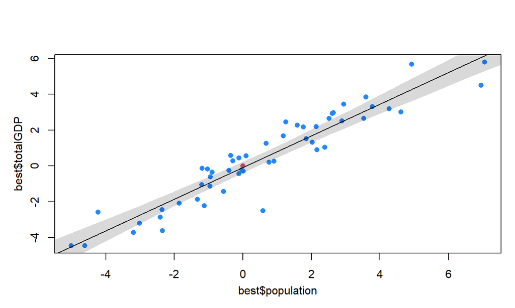

## Plot on the original scale

This steps add to each number the \(log2\) of Czech population and then delogarithmize it by allying the inverse function \(2^x\) on the logarithms. The division by thousand is here to cope with the fact that the original data are in thousands

## Plot on the original scale

```r
addpop<-log(d$population[best$abr=="CZE"]*1000,base=2)
head(cbind(
2^(best$population+addpop)/1000,
d$population)) #Check that it is the same
```

```
##          [,1]     [,2]
## [1,] 23932.50 23932.50
## [2,]  8678.67  8678.67
## [3,] 11287.93 11287.93
## [4,] 36026.67 36026.67
## [5,] 10601.39 10601.39
## [6,]  5688.70  5688.70
```

## Plot on the original scale

```r
myplot(d$population,d$totalGDP)

addgdp<-log(d$totalGDP[best$abr=="CZE"]*1000000,base=2)
orig.scale.x<-2^(x+addpop)/1000
orig.scale.y<-2^(y+addgdp)/1000000

muy<-apply(orig.scale.y,1,mean)
CIy<-apply(orig.scale.y,1,PI,prob=0.95)
lines(orig.scale.x,muy)
shade(CIy,orig.scale.x)
```

## Plot on the original scale

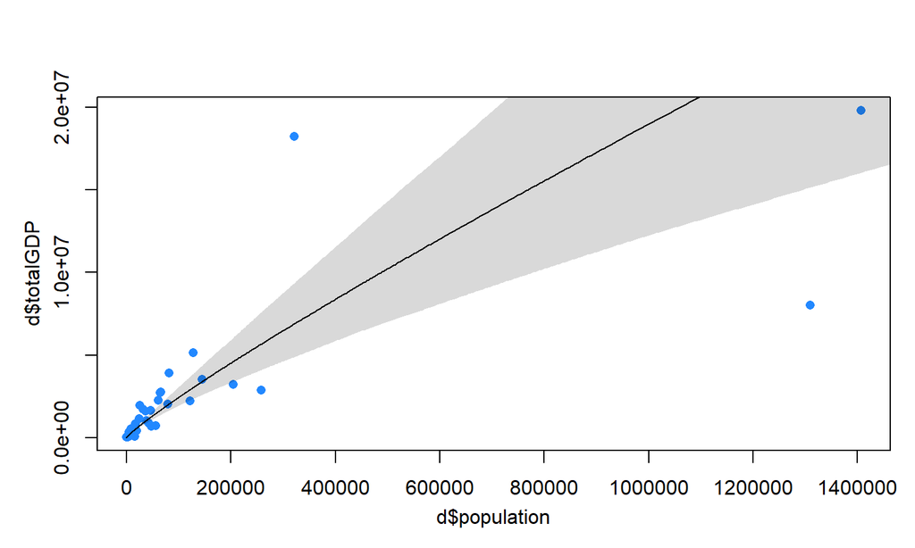

## Why did we bother

to show it all on a system that had to be logarithmized and delogarithmized back a forth? Because logarithms are super important in probability calculations.

Computers are stupid, look:

```r
#We have two vectors of small probabilities
A<-rep(c(0.001,0.0005,0.0003),100)
B<-rep(c(0.001,0.0005,0.0003),50)
```

```
## List of 2
##  $ A: num [1:300] 1e-03 5e-04 3e-04 1e-03 5e-04 3e-04 1e-03 5e-04 3e-04 1e-03 ...
##  $ B: num [1:150] 1e-03 5e-04 3e-04 1e-03 5e-04 3e-04 1e-03 5e-04 3e-04 1e-03 ...
```

## Taking their products

returns simply 0

```r
prod(A)
prod(B)
```

```
## [1] 0 0
```

## But if we log them

```r
logA<-log(A,10)
logB<-log(B,10)
```

## And sum the logs

```r
sumA<-sum(log(A,10))
sumB<-sum(log(B,10))
```

```
## [1] -982.3909 -491.1954
```

We can clearly see, that the resulting probability of B product is much higher than resulting probability of A.

## Power of logarithm

Logarithm scales the positive part of the real number axis such that all numbers between 0 and 1 (most numbers in probability calculations) have the all negative part of the real axis for themselves, which is really useful if we represent continuous numbers on a discrete machine like our computer.